[figure not shown]

Соавторы - Лебедева Виктория, Шарапова Екатерина, Короваева Анастасия.

# *Моделька*

## Постановка задачи

Для нашего проекта мы решили поставить задачу, которая будет каким-то образом связана с направлением нашего обучения в Вышке. Так у нас возникла идея, что в рекламных целях нам надо создать собственный паблик, темой которого будет искусство фотографии и их последующая обработка.

Для анализа мы взяли 7 пабликов, связанные с фотографией и фотошопом, в которых мы выделяем тематики для того, чтобы определить, какой контент будет в нашем паблике. Также мы качаем соцдем по этим 7 группам, чтобы определить примерную целевую аудиторию нашего будущего паблика.

## 1.Обработка данных

```python
import pandas as pd              # Пакет для работы с таблицами
import numpy as np               # Пакет для работы с векторами и матрицами

# Пакеты для графииков
import matplotlib
import matplotlib.pyplot as plt
import seaborn as sns
plt.style.use('ggplot')   # Правильный стиль графиков

%matplotlib inline
```

# Данные

Для данной работы мы взяли 7 групп связанных с обработкой фотографий, в которых мы проанализировали их подписчиков.

- [Обработка фото - Photoshop - Lightroom](https://vk.com/artmilart)
- [Фотография для души](https://vk.com/foto_forsoul)
- [Фотошоп-мастер](https://vk.com/phmaste)
- [Art Family](https://vk.com/club_of_photoshop)
- [Lightroom&Photoshop](https://vk.com/lr_school)
- [Журнал PhotoCasa](https://vk.com/journalphoto)
- [Photoshop + Творчество](https://vk.com/psclub)

```python
publics = ['artmilart.pickle', 'club_of_photoshop.pickle', 'foto_forsoul.pickle',
           'journalphoto.pickle', 'lr_school.pickle', 'phmaste.pickle', 'psclub.pickle']
```

```python
import pickle

data = [ ]

for item in publics:
    with open('' + item, 'rb') as f:
        cur_data = pickle.load(f)
    data.extend(cur_data)
```

```python
len(data)
```

```
6872
```

У нас посчти 7000 стенок, посмотрим на их длину

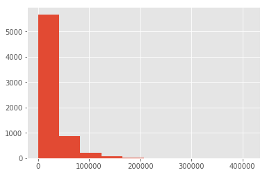

```python
text_len = [len(item['wall']) for item in data]

plt.hist(text_len);
```

Видим, что у нас есть аномально длинные стенки, от которых нужно избавиться. Возьмем квантиль 95%, а также удалим пустые стенки и стенки с маленьким количеством записей.

```python
q = np.quantile(text_len, 0.95)
q
```

```
82475.84999999998
```

```python
texts = [item['wall'] for item in data if item['wall'] != None and 10 < len(item['wall']) < q]
group = [item['group'] for item in data if item['wall'] != None and 10 < len(item['wall']) < q]
```

```python
len(texts)
```

```
6155
```

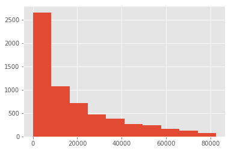

```python
text_len = [len(item) for item in texts]
plt.hist(text_len);
```

```python
len(data)- len(texts)
```

```
717
```

Выборка улучшилась, некачественных данных оказалось 717 стенок.

## 2. Предобработка

```python
from pymystem3 import Mystem

m = Mystem()  # обхявили предобработчик

lemmas = m.lemmatize(texts[-1])  # натравили его на текст
print(lemmas[:50])
```

```
['  ', 'Red', ' ', 'Dead', ' ', 'Redemption', ' ', '2', ' ', 'этот', ' ', 'искусство', '.', '\n', 'DTF', '    ', 'рад', ' ', 'представлять', ' ', 'вы', ' ', 'новый', ' ', 'тречко', '!', '\n', 'Label', ': ', 'Sense', ' ', 'label', '\n', 'Production', ': ', 'by', ' ', 'Granplus', '\n', 'Mastering', ':…
```

```python
# объявили предобработчик с опцией выкидывать пробелы и пунктуацию
m = Mystem(entire_input=False)

lemmas = m.lemmatize(texts[-1])
print(lemmas[:50])
```

```
['Red', 'Dead', 'Redemption', 'этот', 'искусство', 'DTF', 'рад', 'представлять', 'вы', 'новый', 'тречко', 'Label', 'Sense', 'label', 'Production', 'by', 'Granplus', 'Mastering', 'by', 'Pekla', 'Design', 'by', 'Zhelezko', 'слушать', 'https', 'soundcloud', 'com', 'sense', 'label', 'https', 'senselabel…
```

```python
%%time
texts_prep = [m.lemmatize(text) for text in texts]
texts_prep[-1][:50]
```

```
CPU times: user 3min 50s, sys: 18.7 s, total: 4min 9s
Wall time: 18min 40s
```

Прогоняем все тексты через список стоп-слов, чтобы убрать лишнее.

```python
import nltk
nltk.download("stopwords")
```

```
True
```

```python
from nltk.corpus import stopwords

# Например, там лежат стоп-слова
stopwords_ru = stopwords.words('russian')
stopwords_ru[:10]
```

```
['и', 'в', 'во', 'не', 'что', 'он', 'на', 'я', 'с', 'со']
```

На семинаре видели, что во многих тематиках попадаются ссылки, поэтому расширим стоп слова возможными составляющими ссылок.

```python
my_stopwords = ['www','https','ru','http', 'vk', 'id', 'club', '/', 'com']
stopwords_ru += my_stopwords
```

Теперь отчистим все тексты от стоп-слов и смайликов (берем слова длиннее 1).

```python
texts_prep = [[word for word in text if word not in stopwords_ru and len(word) > 1] for text in texts_prep]
```

```python
with open('wall_prep.pickle', 'wb') as f:
    pickle.dump(texts_prep, f)
```

## Словари

Воспользуемся для кластеризации групп по контенту библиотекой `gensim`.

```python
from gensim import corpora, models
```

```python
dictionary = corpora.Dictionary(texts_prep)                 # составляем словарь из терминов
corpus = [dictionary.doc2bow(text) for text in texts_prep]  # составляем корпус документов
```

```python
print(texts_prep[1][:12])
print(corpus[1][:12])
```

```
['красивый', 'дата', 'свадьба', 'год', 'сотрудник', 'загс', 'считать', 'следующий', 'год', 'желающий', 'заключать', 'брак']
[(151, 8), (209, 1), (226, 2), (227, 3), (229, 1), (232, 1), (236, 5), (238, 1), (243, 6), (245, 35), (248, 2), (249, 11)]
```

```python
len(dictionary)
```

```
369721
```

Узнаем, какие слова встречаются в группах очень часто, а какие редко.

```python
# Посмотрим как часто какие слова встречаются в наших текстах
from collections import defaultdict
import itertools

# Команда для строительства графика.
def word_freq_plot(dictionary,corpus, k2=100, k1=0):

    # Создаём по всем текстам словарик с частотами
    total_word_count = defaultdict(int)
    for word_id, word_count in itertools.chain.from_iterable(corpus):
        total_word_count[dictionary.get(word_id)] += word_count

    # Сортируем словарик по частотам
    sorted_word_count = sorted(total_word_count.items(), key=lambda w: w[1], reverse=True)

    # Делаем срез и по этому срезу строим картиночку
    example_list = sorted_word_count[k1:k2]
    word = []
    frequency = []
    for i in range(len(example_list)):
        word.append(example_list[i][0])
        frequency.append(example_list[i][1])

    indices = np.arange(len(example_list))

    plt.figure(figsize=(22,10))
    plt.bar(indices, frequency)
    plt.xticks(indices, word, rotation='vertical',fontsize=12)
    plt.tight_layout()
    pass
```

```
Размер словаря до фильтрации: 369721
```

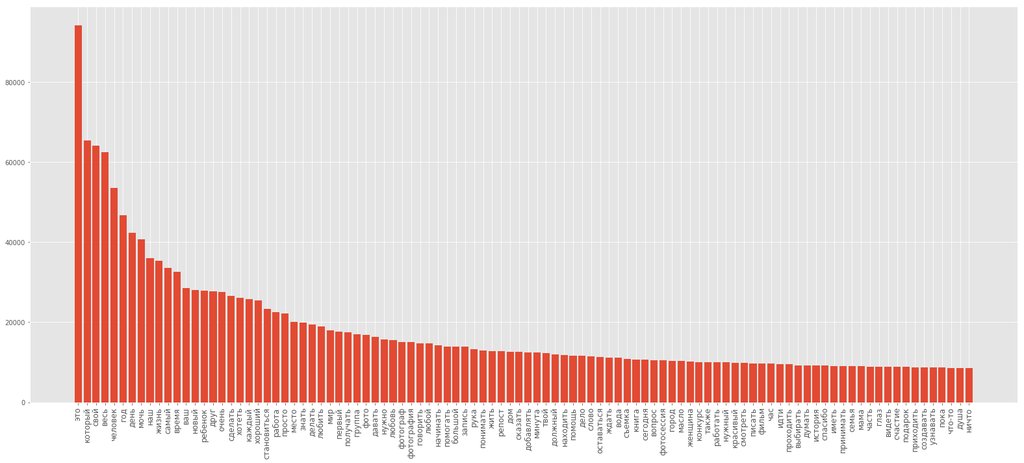

```python
print('Размер словаря до фильтрации: {}'.format(len(dictionary)))
word_freq_plot(dictionary, corpus)
```

Видим, что у нас много бесполезных слов в распределении ("это" на первом месте, а для моделирования оно ничего не даст). Хотя есть слова типа "фото" или "фотосессия", значит фотографы там есть, уже хорошо, в группах есть люди, увлекающиеся фотографией. :)

Будем чистить от стоп-слов и редких слов.

```
Размер словаря после фильтрации: 39061
```

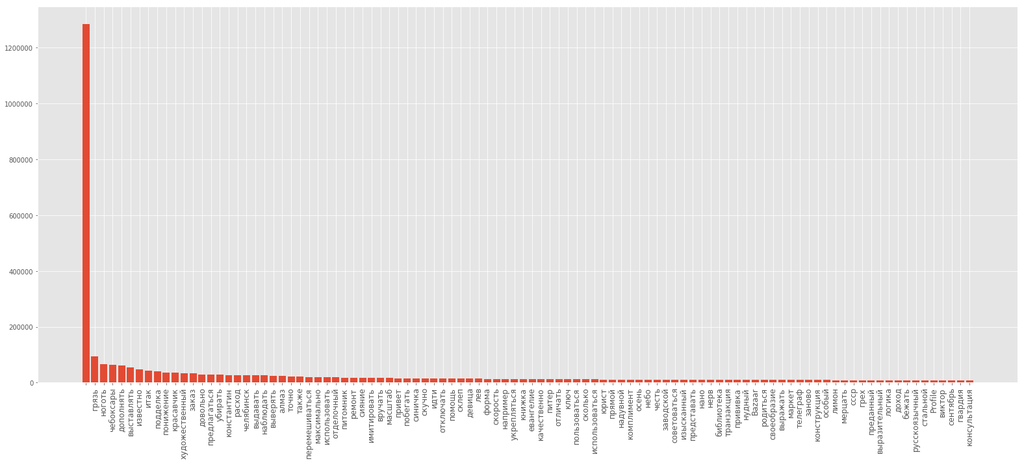

```python
# слово должно встретиться хотябы 10 раз и не более чем в 50% документов
dictionary.filter_extremes(no_below=10, no_above=0.5)

print('Размер словаря после фильтрации: {}'.format(len(dictionary)))
word_freq_plot(dictionary, corpus)
```

```python
# составляем корпус документов по отфиьлтрованному словарю
corpus = [dictionary.doc2bow(text) for text in texts_prep]
```

## Строим LDA модель

Построим первую модель с 12 тематиками. (грузила на другом компьютере)

```python
%%time

T = 12

lda_model =  models.ldamulticore.LdaMulticore(corpus=corpus,       # корпус для обучения
                                             id2word=dictionary,   # словарь для обучения
                                             num_topics=T,         # число тематик, которые мы выделяем
                                             random_state=42,      # чтобы воспроизводилось при перезапуске
                                             passes=20)            # число проходов по коллекции документов
                                                                   # (если долго работает, уменьшите его!)
```

```python
lda_model = models.ldamodel.LdaModel.load('lda_model/ldamodel')

expElogbeta = np.load('lda_model/ldamodel.expElogbeta.npy')
lda_model.expElogbeta = expElogbeta

T = lda_model.num_topics # число тематик
```

```python
# Сохранение модели
model_path = 'lda_model/'

lda_model.save(model_path + "ldamodel")
np.save(model_path + 'explog', lda_model .expElogbeta)
```

```python
lda_model.get_document_topics(corpus[299])
```

[output not shown]

```python
print(texts_prep[299][:50])
```

```
['дорогой', 'родные', 'близкий', 'одноклассник', 'однокашник', 'коллега', 'сослуживец', 'поздравлять', 'новолетие', 'парить', 'орел', 'пожелать', 'хороший', 'здоровье', 'семейный', 'счастие', 'любовь', 'благополучие', 'удача', 'спокойствие', 'тепло', 'весь', 'хороший', 'жить', 'долго', 'любить', 'ра…
```

## Интерпретация тематик

```python
# Загрузка модели
model_path = 'lda_model/'
ldamodel = models.ldamodel.LdaModel.load(model_path + "ldamodel")

expElogbeta = np.load(model_path + 'ldamodel.expElogbeta.npy')
ldamodel.expElogbeta = expElogbeta

T = ldamodel.num_topics # число тематик
T
```

```
12
```

12 тематик - как раз не много и не мало, нам подойдет.

```python
ldamodel.get_document_topics(corpus[99])
```

```
[(0, 0.25839418),
 (1, 0.21570116),
 (5, 0.3706117),
 (8, 0.057923514),
 (9, 0.09599381)]
```

Посмотрим какие слова соответствуют каждой тематике:

```python
topics = lda_model.show_topics(num_topics=T, num_words=20, formatted=False)

for i,top in enumerate(topics):
    print(i, [item[0] for item in top[1]],'\n')
```

```
0 ['сайт', 'дизайн', 'цена', 'cc', 'бизнес', 'рубль', 'руб', 'видео', 'компания', 'магазин', 'вопрос', 'также', 'работать', 'клиент', 'интернет', 'товар', 'бесплатный', 'проект', 'ссылка', 'зарабатывать']

1 ['the', 'to', 'of', 'and', 'The', 'in', 'you', 'is', 'альбом', 'for', 'открытка', 'by', 'английский', 'on', 'it', 'with', 'язык', 'me', 'трек', 'de']

2 ['ряд', 'петля', 'лицо', 'россия', 'см', 'вязать', 'сбн', 'уровень', 'узнавать', 'вязание', 'изна', 'ссылка', 'спица', 'схема', 'район', 'помощь', 'сторона', 'игра', 'советский', 'лицевой']

3 ['твой', 'женщина', 'мужчина', 'мама', 'слово', 'счастие', 'душа', 'думать', 'ничто', 'что-то', 'идти', 'кто-то', 'сердце', 'глаз', 'видеть', 'счастливый', 'никто', 'нужный', 'пусть', 'отношение']

4 ['собака', 'животное', 'дом', 'малыш', 'помощь', 'кошка', 'щенок', 'хозяин', 'кот', 'нужный', 'месяц', 'добрый', 'искать', 'возраст', 'девочка', 'котенок', 'улица', 'семья', 'репост', 'тело']

5 ['книга', 'создавать', 'фотография', 'слой', 'использовать', 'иметь', 'работать', 'цвет', 'свет', 'также', 'Ctrl', 'выбирать', 'являться', 'помощь', 'урок', 'изображение', 'часть', 'мозг', 'глаз', 'слово']

6 ['масло', 'добавлять', 'минута', 'вода', 'яйцо', 'сахар', 'тесто', 'соль', 'ингредиент', 'приготовление', 'мука', 'ложка', 'ст', 'сыр', 'нарезать', 'шт', 'вкус', 'перец', 'лук', 'гр']

7 ['город', 'спасибо', 'дом', 'твой', 'проходить', 'рождение', 'лето', 'душа', 'идти', 'приходить', 'счастие', 'думать', 'слово', 'москва', 'утро', 'фото', 'ночь', 'прекрасный', 'любимый', 'видеть']

8 ['фотограф', 'photo', 'фото', 'photographer', 'фотосессия', 'instagram', 'Ph', 'свадьба', 'фотография', 'свадебный', 'модель', 'Md', 'love', 'ph', 'photography', 'WhatsApp', 'md', 'запись', 'спасибо', 'wedding']

9 ['репост', 'конкурс', 'запись', 'розыгрыш', 'победитель', 'приз', 'участие', 'условие', 'участник', 'подарок', 'помощь', 'итог', 'декабрь', 'подписываться', 'удача', 'подписчик', 'приложение', 'случайный', 'узнавать', 'выбирать']

10 ['съемка', 'фото', 'фотосессия', 'фотограф', 'фотография', 'студия', 'запись', 'фотостудия', 'красивый', 'новогодний', 'модель', 'макияж', 'стоимость', 'спасибо', 'писать', 'платье', 'образ', 'праздник', 'подарок', 'семейный']

11 ['фильм', 'история', 'жанр', 'книга', 'война', 'дом', 'сша', 'страна', 'город', 'герой', 'режиссер', 'стена', 'век', 'русский', 'великий', 'часть', 'главный', 'художник', 'драма', 'игра']
```

На основе выявленных слов придумаем подходящие названия нашим тематикам:

```python
themes_names= {
    0: 'Бизнес',
    1: 'Английский язык',
    2: 'Вязание',
    3: 'Близкие люди',
    4: 'Животные',
    5: 'Уроки по обработке фото',
    6: 'Рецепты',
    7: 'Городской пейзаж',
    8: 'Услуги фотографа',
    9: 'Конкурсы',
    10: "Фотосессия",
    11: 'Искусство'}
```

Как мы видим, у нас вышло 3 сегмента, связанных с фотографией. Это "Уроки по обработке фото", "Услуги фотографа" и "Фотосессия". Много довольно "творческих" тематик, типа "Искусство" и "Вязание". Возможно это связано с тем, что фотографией увлекаются творческие люди. Мы можем предположить, что они как-то связаны между собой, а люди в них пересекаются. Сейчас построим для каждой темы облака из слов, чтобы понять, какие слова они употребляют чаще всего и ничего ли мы не упустили.

```python
from wordcloud import WordCloud  # Пакет для построения облаков слов

def getTopicWords(topic_number, lda_30_topics, scaling=10000):
    """
        Возвращает склеенные в текст слова топика, отмасштабированные по вероятности
    """
    # забираем слова и вероятности из топиков
    topic = lda_30_topics[topic_number][1]
    # инициализируем пустой лист для хранения текста
    topic_multiplied = []
    # проходимся по всем словам топика
    for word, prob in topic:
        # повторяем слово N раз, где N = int(word_probability * scaling)
        topic_multiplied.append([word] * int(prob*scaling))

    # склеиваем все слова в один текст
    topic_multiplied = sum(topic_multiplied, [])
    topic_multiplied = ",".join(topic_multiplied)

    return topic_multiplied
```

```python
topics = ldamodel.show_topics(num_topics=T, num_words=500, formatted=False)
```

Теперь можем построить картинки.

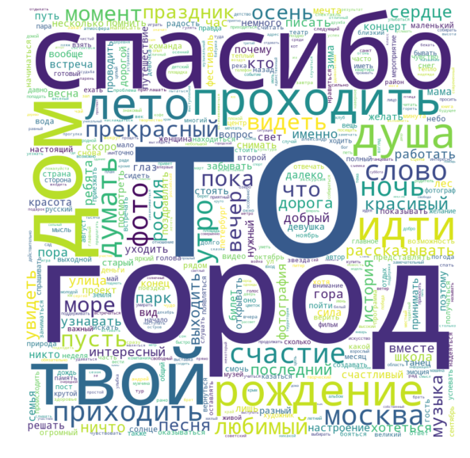

```python
wordcloud = WordCloud(background_color="white", max_words=2000, width=900, height=900, collocations=False)

wordcloud = wordcloud.generate(getTopicWords(7, topics, scaling=10000))

plt.figure(figsize=(15, 10))
plt.imshow(wordcloud, interpolation='bilinear')
plt.axis("off");
```

Строим много картинок!!!

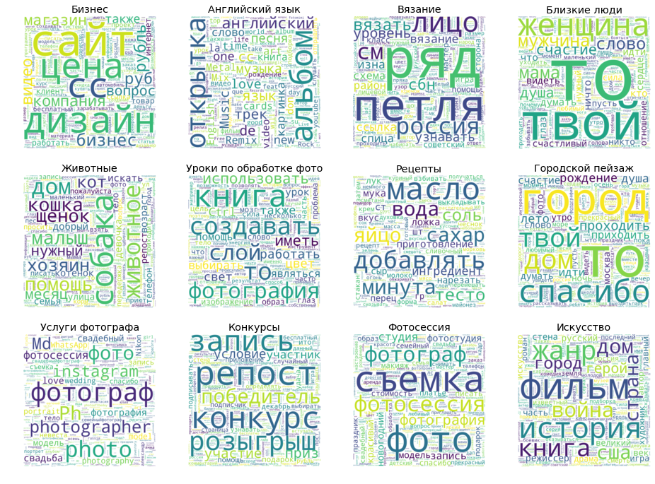

```python
fig = plt.figure(figsize=(16, 20))
for i in range(T):
    ax = fig.add_subplot(5, 4, i+1)
    ax.grid(False)
    ax.axis('off')

    wordcloud = WordCloud(background_color="white", max_words=2000, width=900, height=900, collocations=False)
    wc = wordcloud.generate(getTopicWords(i, topics, scaling=10000))

    ax.imshow(wc, interpolation='bilinear')
    ax.set_title("{}".format(themes_names[i]))
```

Как мы видим, большинству тематик мы дали правильное название.

А теперь наконец смотрим корреляцию!

```python
# матрица тем
Phi = ldamodel.state.get_lambda()
print(Phi.shape)

S = pd.DataFrame(Phi.T).corr()
```

```
(12, 39061)
```

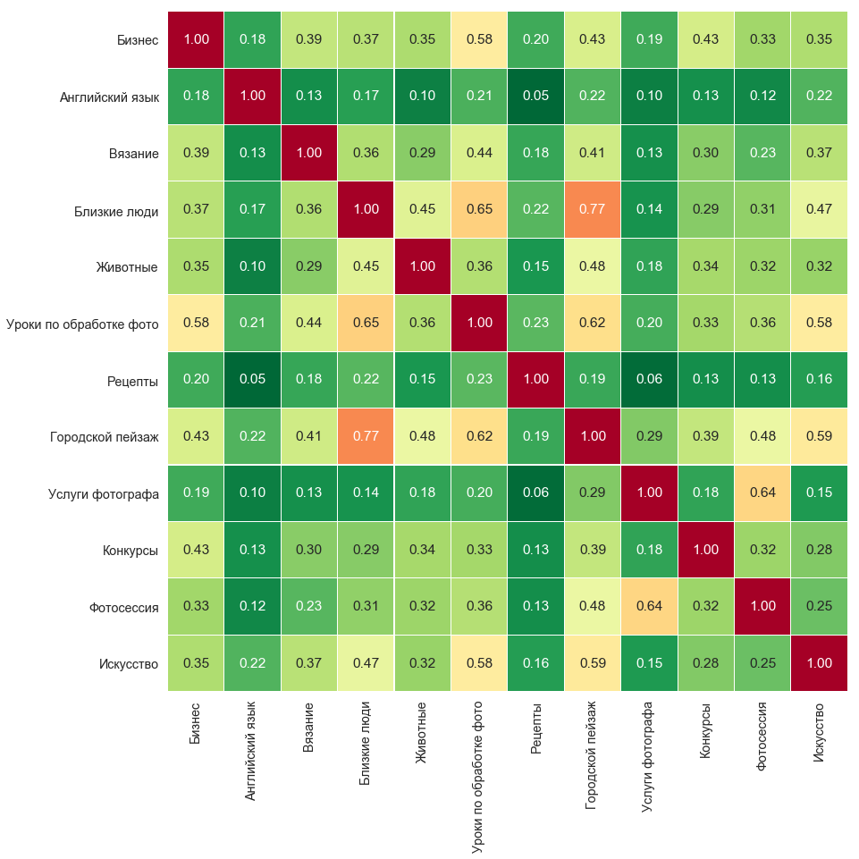

```python
sns.set(font_scale=1.3)
plt.subplots(figsize=(14, 14))
sns.heatmap(S, square=True,
            annot=True, fmt=".2f", linewidths=0.1, cmap="RdYlGn_r",
            yticklabels=list(themes_names.values()),
            xticklabels=list(themes_names.values()),
            cbar=False);
```

Начнём с того, что посмотрим, коррелируют ли между собой подтемы с фотографиями. Их у нас всего 3 - "уроки по обработке фото", "услуги фотографа" и "фотосессия".

По матрице мы видим, что уровень зависимости между подтемами "услуги фотографа" и "фотосессия" довольно высокий. А вот подтема "уроки по обработке фото" связана с ними обеими довольно слабо. Возможно, это происходит из-за того, что в первых двух группах примерно одни и те же люди и фотографы ищут друг друга, а в последней находятся только фотографы и они хотят достигнуть другой цели - научиться.

С чем ещё связаны эти три группы? У "уроков по обработке фото" довольно сильная корреляция с "бизнесом", "близкими людьми" "городским пейзажем" и "искусством". Скорее всего это либо люди, которые хотят обучиться фотографии и зарабатывать на этом ("бизнес"), либо занимающиеся этим для души ("близкие люди, "искусство"). Те, кто связан с" городским пейзажем", скорее всего занимаются обработкой именно таких фотографий. У "услуг фотографа" кроме "фотосессии" нет больше ни с чем корреляции. Скорее всего для этих людей, это главная целей и они отбрасывают все лишнее. "Фотосессия" связана с "городским пейзажем". Скорее всего это из-за того, что большая часть людей заинтересована в фотосессии на улице.

Посмотрим на оставшиеся категории, тут явных корреляций не так много, из самых интересных можно отметить, что "городской пейзаж" сильно связан с "близкими людьми". Скорее всего это связано, что люди, выкладывающие публикации с фотографиями пейзажей любят также семейные фотографии и фотографии с близкими людми. Также видим, что "близкие люди" связаны с "искусством".

## Визуализация тематик

Строим визуализацию наших данных.

```python
import pyLDAvis.gensim
pyLDAvis.enable_notebook()
vis = pyLDAvis.gensim.prepare(ldamodel, corpus, dictionary=ldamodel.id2word)
vis
```

[interactive chart not shown]

Эта красивая табличка дает нам очень много данных, которые довольно сложно описать коротко. Однако эти данные мы точно можно использовать при составление контент-плана, чтобы создавать посты, которые будут пользоваться популярностью и пользователи захотят сделать репост себе на стенку.

# Таблички с тематическими профилями

Делаем матрицу встречаемости тем на разных стенах.

```python
%%time
th_df = []  # матрица документы на темы

for item in corpus:
    dct = dict(zip(range(T), [0]*T))
    dct.update(dict(ldamodel.get_document_topics(item)))
    th_df.append(dct)

th_df = pd.DataFrame(th_df)
```

```
CPU times: user 18.2 s, sys: 1.06 s, total: 19.3 s
Wall time: 9.95 s
```

```python
th_df.columns = list(themes_names.values()) #создаем колонки
th_df.shape
```

```
(6155, 12)
```

```python
th_df.head()
```

|  | Бизнес | Английский язык | Вязание | Близкие люди | Животные | Уроки по обработке фото | Рецепты | Городской пейзаж | Услуги фотографа | Конкурсы | Фотосессия | Искусство |
| --- | --- | --- | --- | --- | --- | --- | --- | --- | --- | --- | --- | --- |
| 0 | 0.842433 | 0.000000 | 0.000000 | 0.000000 | 0.021857 | 0.000000 | 0.000000 | 0.053904 | 0.000000 | 0.059033 | 0.000000 | 0.022582 |
| 1 | 0.000000 | 0.000000 | 0.000000 | 0.000000 | 0.000000 | 0.048649 | 0.035927 | 0.236579 | 0.042569 | 0.469166 | 0.114813 | 0.047210 |
| 2 | 0.000000 | 0.000000 | 0.000000 | 0.985617 | 0.000000 | 0.000000 | 0.000000 | 0.000000 | 0.000000 | 0.000000 | 0.000000 | 0.000000 |
| 3 | 0.000000 | 0.000000 | 0.093479 | 0.000000 | 0.068061 | 0.046472 | 0.010063 | 0.519568 | 0.000000 | 0.081182 | 0.077910 | 0.103057 |
| 4 | 0.000000 | 0.179159 | 0.000000 | 0.044115 | 0.361587 | 0.000000 | 0.000000 | 0.258644 | 0.000000 | 0.128220 | 0.027914 | 0.000000 |

Смотрим, какие темы встречаются чаще всего:

```python
from collections import Counter
top_th = Counter([themes_names[item] for item in th_df.get_values().argmax(axis=1)])
top_th.most_common()
```

```
[('Близкие люди', 1387),
 ('Городской пейзаж', 839),
 ('Конкурсы', 678),
 ('Уроки по обработке фото', 588),
 ('Фотосессия', 550),
 ('Бизнес', 464),
 ('Искусство', 416),
 ('Английский язык', 385),
 ('Рецепты', 360),
 ('Услуги фотографа', 212),
 ('Вязание', 150),
 ('Животные', 126)]
```

Смотрите, первые темы вовсе не связаны с фотографией. Это "близкие люди", "городской пейзаж" и "конкурсы". Всё связано с разным, забавно, однако нужно использовать это.

Подписчики любям конкурсы, надо взять это на заметку при создании контента. Стоит постить фотки, связанные с красивыми пейзажами и близкими людьми (к примеру, семьей, фотографиями детей и пр.).

Обязательно нужно будет уделить внимание создании рубрики с уроками по обработке.

```python
th_df['group'] = group #добавили названия групп
th_df.head()
```

|  | Бизнес | Английский язык | Вязание | Близкие люди | Животные | Уроки по обработке фото | Рецепты | Городской пейзаж | Услуги фотографа | Конкурсы | Фотосессия | Искусство | group |
| --- | --- | --- | --- | --- | --- | --- | --- | --- | --- | --- | --- | --- | --- |
| 0 | 0.842433 | 0.000000 | 0.000000 | 0.000000 | 0.021857 | 0.000000 | 0.000000 | 0.053904 | 0.000000 | 0.059033 | 0.000000 | 0.022582 | artmilart |
| 1 | 0.000000 | 0.000000 | 0.000000 | 0.000000 | 0.000000 | 0.048649 | 0.035927 | 0.236579 | 0.042569 | 0.469166 | 0.114813 | 0.047210 | artmilart |
| 2 | 0.000000 | 0.000000 | 0.000000 | 0.985617 | 0.000000 | 0.000000 | 0.000000 | 0.000000 | 0.000000 | 0.000000 | 0.000000 | 0.000000 | artmilart |
| 3 | 0.000000 | 0.000000 | 0.093479 | 0.000000 | 0.068061 | 0.046472 | 0.010063 | 0.519568 | 0.000000 | 0.081182 | 0.077910 | 0.103057 | artmilart |
| 4 | 0.000000 | 0.179159 | 0.000000 | 0.044115 | 0.361587 | 0.000000 | 0.000000 | 0.258644 | 0.000000 | 0.128220 | 0.027914 | 0.000000 | artmilart |

```python
th_df.to_csv('theme_data.tsv', sep='\t', index=False) # сохранили данные
```

# Профили по группам

```python
th_df = pd.read_csv('theme_data.tsv', sep='\t')  # считали данные
th_df.head()
```

|  | Бизнес | Английский язык | Вязание | Близкие люди | Животные | Уроки по обработке фото | Рецепты | Городской пейзаж | Услуги фотографа | Конкурсы | Фотосессия | Искусство | group |
| --- | --- | --- | --- | --- | --- | --- | --- | --- | --- | --- | --- | --- | --- |
| 0 | 0.842433 | 0.000000 | 0.000000 | 0.000000 | 0.021857 | 0.000000 | 0.000000 | 0.053904 | 0.000000 | 0.059033 | 0.000000 | 0.022582 | artmilart |
| 1 | 0.000000 | 0.000000 | 0.000000 | 0.000000 | 0.000000 | 0.048649 | 0.035927 | 0.236579 | 0.042569 | 0.469166 | 0.114813 | 0.047210 | artmilart |
| 2 | 0.000000 | 0.000000 | 0.000000 | 0.985617 | 0.000000 | 0.000000 | 0.000000 | 0.000000 | 0.000000 | 0.000000 | 0.000000 | 0.000000 | artmilart |
| 3 | 0.000000 | 0.000000 | 0.093479 | 0.000000 | 0.068061 | 0.046472 | 0.010063 | 0.519568 | 0.000000 | 0.081182 | 0.077910 | 0.103057 | artmilart |
| 4 | 0.000000 | 0.179159 | 0.000000 | 0.044115 | 0.361587 | 0.000000 | 0.000000 | 0.258644 | 0.000000 | 0.128220 | 0.027914 | 0.000000 | artmilart |

Делаем группировку по всем темам для того, чтобы посмотреть как именно они выглядят по подписчикам и где у них отличия.

```python
groups_themes = th_df.groupby('group').mean()
groups_themes
```

| group | Бизнес | Английский язык | Вязание | Близкие люди | Животные | Уроки по обработке фото | Рецепты | Городской пейзаж | Услуги фотографа | Конкурсы | Фотосессия | Искусство |
| --- | --- | --- | --- | --- | --- | --- | --- | --- | --- | --- | --- | --- |
| artmilart | 0.101930 | 0.057591 | 0.033022 | 0.200106 | 0.030027 | 0.073696 | 0.044275 | 0.122222 | 0.030173 | 0.142947 | 0.094554 | 0.062731 |
| club_of_photoshop | 0.051082 | 0.068814 | 0.028893 | 0.219962 | 0.030126 | 0.089499 | 0.061883 | 0.127707 | 0.051610 | 0.098338 | 0.081428 | 0.084385 |
| foto_forsoul | 0.031012 | 0.073082 | 0.039026 | 0.208988 | 0.029751 | 0.082088 | 0.060950 | 0.168131 | 0.038173 | 0.097659 | 0.093962 | 0.072066 |
| journalphoto | 0.041581 | 0.063052 | 0.023108 | 0.164450 | 0.026918 | 0.109436 | 0.054408 | 0.146791 | 0.070337 | 0.074845 | 0.133279 | 0.085667 |
| lr_school | 0.046388 | 0.092233 | 0.022978 | 0.202021 | 0.030399 | 0.093750 | 0.036754 | 0.142068 | 0.055820 | 0.087911 | 0.105665 | 0.075466 |
| phmaste | 0.092932 | 0.064099 | 0.036882 | 0.202943 | 0.032562 | 0.090080 | 0.063779 | 0.104458 | 0.024939 | 0.140052 | 0.063089 | 0.076907 |
| psclub | 0.110672 | 0.074702 | 0.021292 | 0.203564 | 0.015217 | 0.123477 | 0.055647 | 0.078015 | 0.019841 | 0.176216 | 0.049424 | 0.067656 |

Опять смотрим корреляцию, но уже по группам и темам:

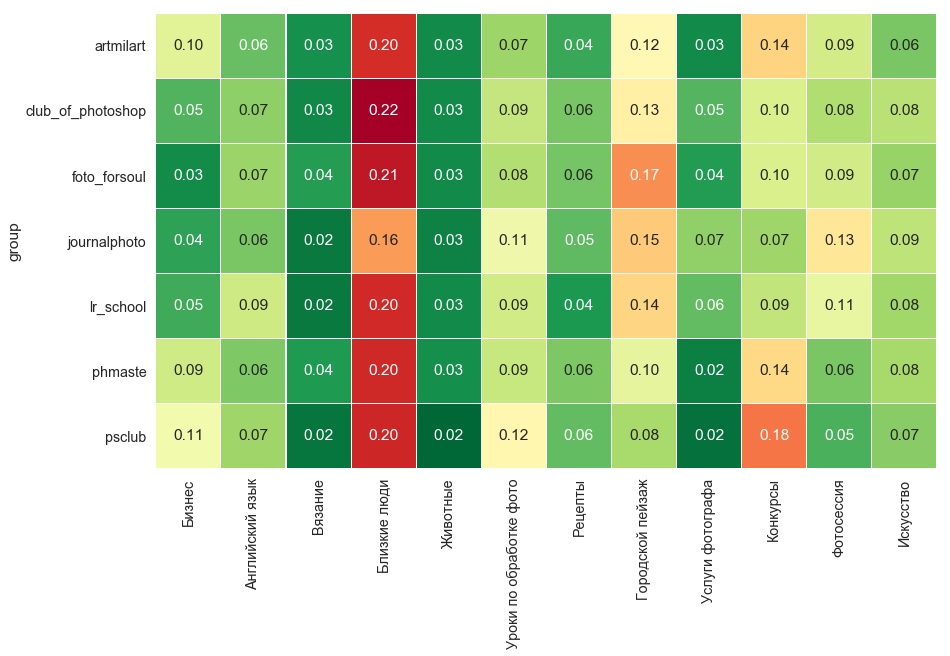

```python
sns.set(font_scale=1.3)
plt.subplots(figsize=(14, 14))

sns.heatmap(groups_themes, square=True,
            annot=True, fmt=".2f", linewidths=0.1, cmap="RdYlGn_r",
            yticklabels=list(groups_themes.index),
            xticklabels=list(groups_themes.columns),
            cbar=False);
```

Зануляем все маргинальные темы (для большей наглядности):

```python
groups_themes[groups_themes < 0.03] = 0
```

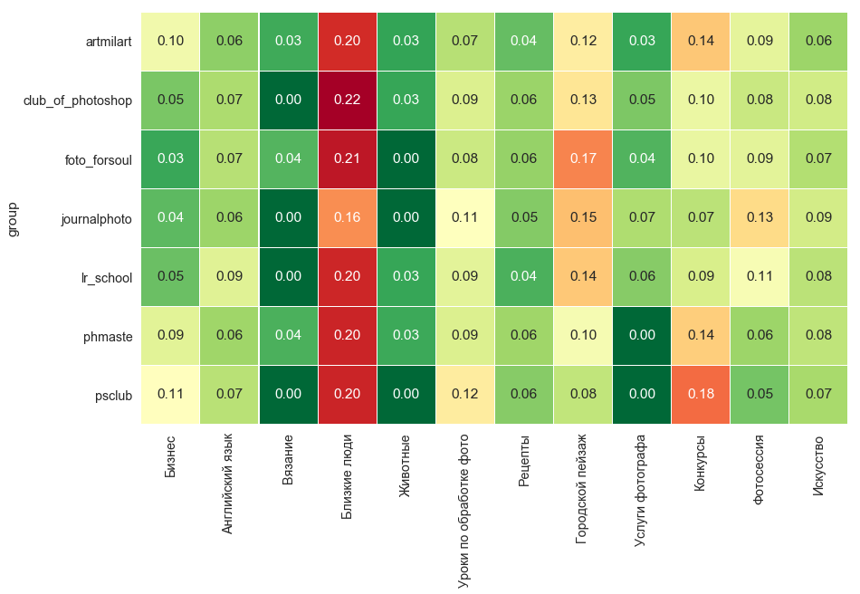

```python
sns.set(font_scale=1.3)
plt.subplots(figsize=(14, 14))

sns.heatmap(groups_themes, square=True,
            annot=True, fmt=".2f", linewidths=0.1, cmap="RdYlGn_r",
            yticklabels=list(groups_themes.index),
            xticklabels=list(groups_themes.columns),
            cbar=False);
```

Давайте поподробнее рассмотрим в каком сообществе какая тема популярнее.

Итак, на графике корреляций мы можем видеть, что во всех пабликах очень распространена тематика "близкие люди", в неё у нас входили слова: женщина, мама, счастье, душа, нужный и многие другие, это говорит о том, что и в нашем паблике стоит использовать данную тематику.

Также большой интерес представляет для нас тематика "городской пейзаж", она представлена во многих группах в достаточном количестве. Там представлены такие слова, как Москва, ночь, город, возможно людям нравятся ночные пейзажи Москвы, фото городской архитектуры.

Третьими по распространённости в 7 анализируемых группах будет тематика "конкурсы", тут мы можем предположить, что аудитории этих пабликов нравятся конкурсы и розыгрыши.

Ещё раз посмотрев на распределение мы замечаем, что тематики "вязание" и "животные" в пабликах про фотографию являются менее интересными, это говорит о том, что нам стоит посмотреть на другие наши тематики. Хотя мы и знаем, как популярны видео с кошечками на ютубе, видимо в нашем случае не стоит постить фотографии кошечек и других животных.

# Похожесть групп

Косинусным расстоянием померяем похожесть групп.

```python
from scipy.spatial.distance import cosine

n = groups_themes.shape[0]  # выясняем число групп
R = np.zeros((n,n))         # заводим матрицу расстояний


for i in range(n):
    vect1 = groups_themes.iloc[i]     # выделяем вектор для первого
    for j in range(n):
        vect2 = groups_themes.iloc[j] # выделяем второй вектор
        R[i,j] = cosine(vect1, vect2) # ищем косинусное расстояние
```

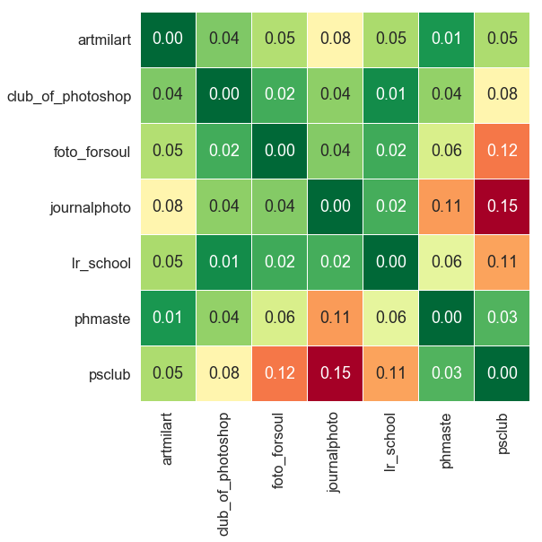

```python
sns.set(font_scale=1.5)
plt.subplots(figsize=(8, 8))
sns.heatmap(R, square=True,
            annot=True, fmt=".2f", linewidths=0.1, cmap="RdYlGn_r",
            yticklabels=list(groups_themes.index),
            xticklabels=list(groups_themes.index), cbar=False);
```

На данном графике мы можем видеть корреляцию между пабликами, которые мы рассматриваем в нашем проекте. Итак, мы можем видеть, что самые несхожие паблики - это journalphoto и psclub, ещё psclub не схож с foto_forsoul и lr_school. Скорее всего это обусловлено тем, что контент в этих группах различный. А вот если рассматривать самые схожие страницы, то тут парами будут: phmaste и artmilart, lr_school и dub_of_photoshop. Хотела бы я сделать точный вывод по пабликам, которые связаны с лайтрумом и фотошопом, однако у нас есть паблики на эти программы, которые очень схожи, но есть и те, которые очень отличаются. Возможно, что в группах, которые очень схожи контент на самом деле включает в себя какие-то фото с обработкой в обоих приложениях, а вот с теми пабликами, которые очень отличаются, может быть такое, что люди, которые подписались на паблик про одно приложение не интересуются другим.

### Профиль подписчика

Теперь, после того как мы определились с тематиками нашего паблика, было бы классно понять кто будет там сидеть. Посмотрим самые популярные города среди всех подписчиков пабликов и узнаем распределение полов.

```python
with open('group_clean_members_extended.pickle', 'rb') as f:
    members = pickle.load(f)
```

```python
parametrs = {} # тут будут хранится город и пол и соответствующее им количество людей по пабликам
```

```python
for name_group in members.keys(): # заполняем parametrs
    parametrs[name_group] = {'sex': {}, 'city': {}}
    for person in members[name_group]:
        try:
            city = person['city']['title']
            try:
                parametrs[name_group]['city'][city] += 1
            except:
                parametrs[name_group]['city'][city] = 0
        except:
            pass

        try:
            sex = person['sex']
            try:
                parametrs[name_group]['sex'][sex] += 1
            except:
                parametrs[name_group]['sex'][sex] = 0
        except:
            pass
```

```python
#Переведе в процентное соотношение наши данные
for name_group in parametrs.keys():
    for p in parametrs[name_group].keys():
        sum_value = sum(parametrs[name_group][p].values())
        for v in parametrs[name_group][p].keys():
            parametrs[name_group][p][v] = parametrs[name_group][p][v]/sum_value*100
```

```python
# создадим функции для создания Датафрэйма с полом и городом по пабликам
def city_sort(name):
    df = pd.DataFrame({'city': list(parametrs[name]['city'].keys()), 'percentange': list(parametrs[name]['city'].values())})
    df = df.sort_values(ascending=False, by=['percentange'])
    return df.head()

def sex_sort(name):
    df = pd.DataFrame({'sex': list(parametrs[name]['sex'].keys()), 'percentange': list(parametrs[name]['sex'].values())})
    df = df.sort_values(ascending=False, by=['percentange'])
    return df.head()
```

```python
a = {} # тут будут города и их процентное соотношение по паблткам
for k in parametrs.keys():
    a[k] = city_sort(k)
```

```python
a['foto_forsoul']
```

|  | city | percentange |
| --- | --- | --- |
| 3 | Москва | 16.499036 |
| 2 | Санкт-Петербург | 12.246600 |
| 23 | Киев | 2.756788 |
| 48 | Минск | 2.506644 |
| 15 | Новосибирск | 2.032414 |

```python
b = {} # тут будет пол и процентное соотношение по пабликам
for k in parametrs.keys():
    b[k] = sex_sort(k)
```

```python
b['foto_forsoul']
```

|  | sex | percentange |
| --- | --- | --- |
| 0 | 1 | 66.669387 |
| 1 | 2 | 33.277558 |
| 2 | 0 | 0.053055 |

# Выводы

Итак, мы посмотрели на 7 пабликов, связанных с фотографией. Посмотрев на стенки подписчиков выяснили, что в них действительно довольно много фотографов, так как у нас довольно популярными тематиками стали "Фотосессия" и "Уроки по обработке фото". Помимо фотографов в таких пабликах сидят творческие люди, например, увлекающиеся вязанием или которым нравятся красивые пейзажи.

Средним портретом подписчика такого паблика является девушка из Москвы, поэтому наши посты должны быть ориентированы именно на нее. Хотя среди подписчиков много фотографов, самая популярная категория это "близкие люди", что может говорить о том, что средний подписчик, это девушка, которая ценит свою семью и близких людей (постит фотографии с детьми или любимым человеков в инстаграм). При создании контента мы должны стараться учитывать как интересы профессиональных фотографов, но и не забывать о том, что много людей, не так сильно увлекающихся фотографией, поэтому нам следует избегать сложных терминов и постить разнообразных контент. Например, кроме профессиональных уроков по обработке в фотошопе стоит выкладывать и упрощенные варианты.